# Übung Extremwerte raushauen

Sebastian Sauer

2022-06-24

Pakete starten:

```r
library(tidyverse)
```

Daten laden:

```r
data("flights", package = "nycflights13")
```

Was ist der Flug mit der größten Verspätung?

```r
flights %>%
  arrange(-dep_delay)
```

```
## # A tibble: 336,776 × 19
##     year month   day dep_time sched_dep_time dep_delay arr_time sched_arr_time
##    <int> <int> <int>    <int>          <int>     <dbl>    <int>          <int>
##  1  2013     1     9      641            900      1301     1242           1530
##  2  2013     6    15     1432           1935      1137     1607           2120
##  3  2013     1    10     1121           1635      1126     1239           1810
##  4  2013     9    20     1139           1845      1014     1457           2210
##  5  2013     7    22      845           1600      1005     1044           1815
##  6  2013     4    10     1100           1900       960     1342           2211
##  7  2013     3    17     2321            810       911      135           1020
##  8  2013     6    27      959           1900       899     1236           2226
##  9  2013     7    22     2257            759       898      121           1026
## 10  2013    12     5      756           1700       896     1058           2020
## # … with 336,766 more rows, and 11 more variables: arr_delay <dbl>,
## #   carrier <chr>, flight <int>, tailnum <chr>, origin <chr>, dest <chr>,
## #   air_time <dbl>, distance <dbl>, hour <dbl>, minute <dbl>, time_hour <dttm>
```

Sie könnten synonym auch schreiben:

```r
arrange(flights, -dep_delay)
```

```
## # A tibble: 336,776 × 19
##     year month   day dep_time sched_dep_time dep_delay arr_time sched_arr_time
##    <int> <int> <int>    <int>          <int>     <dbl>    <int>          <int>
##  1  2013     1     9      641            900      1301     1242           1530
##  2  2013     6    15     1432           1935      1137     1607           2120
##  3  2013     1    10     1121           1635      1126     1239           1810
##  4  2013     9    20     1139           1845      1014     1457           2210
##  5  2013     7    22      845           1600      1005     1044           1815
##  6  2013     4    10     1100           1900       960     1342           2211
##  7  2013     3    17     2321            810       911      135           1020
##  8  2013     6    27      959           1900       899     1236           2226
##  9  2013     7    22     2257            759       898      121           1026
## 10  2013    12     5      756           1700       896     1058           2020
## # … with 336,766 more rows, and 11 more variables: arr_delay <dbl>,
## #   carrier <chr>, flight <int>, tailnum <chr>, origin <chr>, dest <chr>,
## #   air_time <dbl>, distance <dbl>, hour <dbl>, minute <dbl>, time_hour <dttm>
```

Synonym:

```r
flights %>%
  drop_na(dep_delay) %>%
  filter(dep_delay == max(dep_delay))
```

```
## # A tibble: 1 × 19
##    year month   day dep_time sched_dep_time dep_delay arr_time sched_arr_time
##   <int> <int> <int>    <int>          <int>     <dbl>    <int>          <int>
## 1  2013     1     9      641            900      1301     1242           1530
## # … with 11 more variables: arr_delay <dbl>, carrier <chr>, flight <int>,
## #   tailnum <chr>, origin <chr>, dest <chr>, air_time <dbl>, distance <dbl>,
## #   hour <dbl>, minute <dbl>, time_hour <dttm>
```

Visualisieren Sie die Verteilung von `dep_delay` und entscheiden Sie, ob Extremwerte vorkommen, die besonderer Behandlung bedürfen!

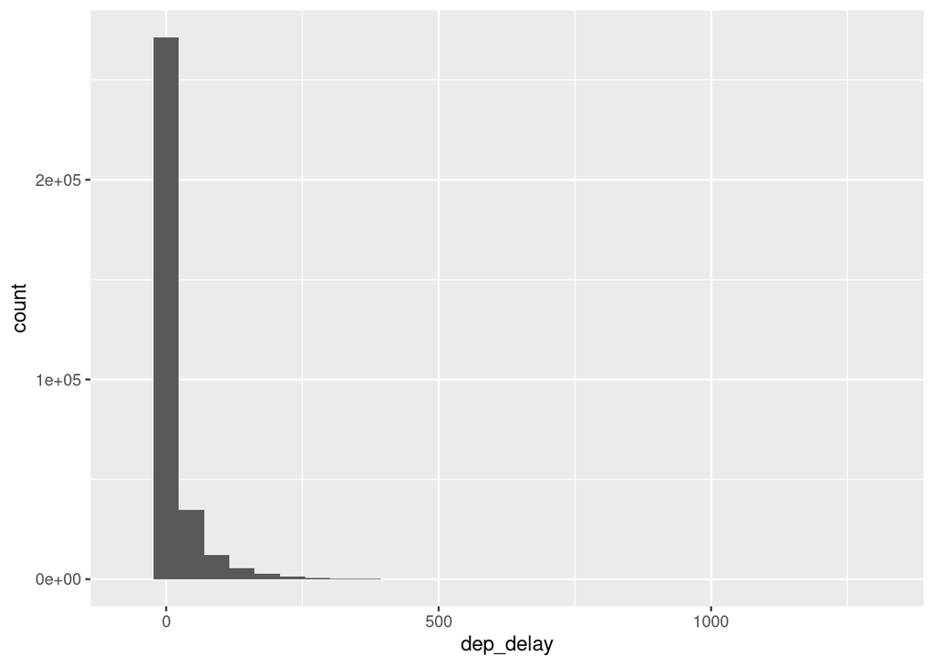

```r
flights %>%
  ggplot() +
  aes(x = dep_delay) +
  geom_histogram()
```

Unterscheiden sich die New Yorker Flughäfen in ihrer (Verteilung) der Verspätung?

Um diese Frage zu beantworten, kann man deskriptive Statistik oder Visualisierung(en) bemühen.

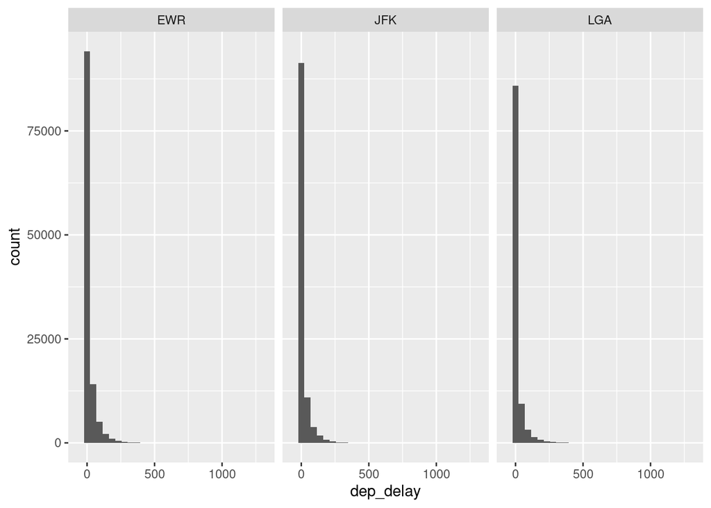

```r
flights %>%
  ggplot() +
  aes(x = dep_delay) +
  geom_histogram() +
  facet_wrap(~ origin)
```

Vielleicht besser mit Boxplots:

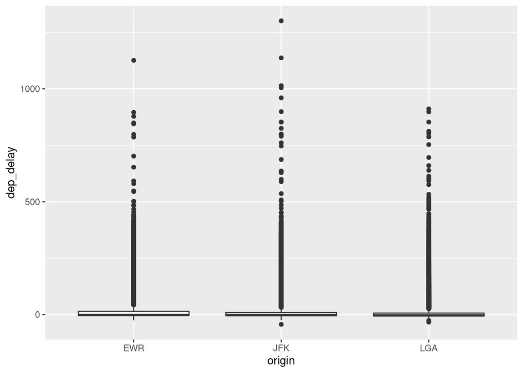

```r
flights %>%
  ggplot() +
  aes(x = origin, y = dep_delay) +
  geom_boxplot()
```

Geben Sie die typischen deskriptiven Statistiken für `dep_delay` an, am besten runtergebrochen pro Abflugsort (`origin`).

```r
summary(flights)
```

```
##       year          month             day           dep_time    sched_dep_time
##  Min.   :2013   Min.   : 1.000   Min.   : 1.00   Min.   :   1   Min.   : 106
##  1st Qu.:2013   1st Qu.: 4.000   1st Qu.: 8.00   1st Qu.: 907   1st Qu.: 906
##  Median :2013   Median : 7.000   Median :16.00   Median :1401   Median :1359
##  Mean   :2013   Mean   : 6.549   Mean   :15.71   Mean   :1349   Mean   :1344
##  3rd Qu.:2013   3rd Qu.:10.000   3rd Qu.:23.00   3rd Qu.:1744   3rd Qu.:1729
##  Max.   :2013   Max.   :12.000   Max.   :31.00   Max.   :2400   Max.   :2359
##                                                  NA's   :8255
##    dep_delay          arr_time    sched_arr_time   arr_delay
##  Min.   : -43.00   Min.   :   1   Min.   :   1   Min.   : -86.000
##  1st Qu.:  -5.00   1st Qu.:1104   1st Qu.:1124   1st Qu.: -17.000
##  Median :  -2.00   Median :1535   Median :1556   Median :  -5.000
##  Mean   :  12.64   Mean   :1502   Mean   :1536   Mean   :   6.895
##  3rd Qu.:  11.00   3rd Qu.:1940   3rd Qu.:1945   3rd Qu.:  14.000
##  Max.   :1301.00   Max.   :2400   Max.   :2359   Max.   :1272.000
##  NA's   :8255      NA's   :8713                  NA's   :9430
##    carrier              flight       tailnum             origin
##  Length:336776      Min.   :   1   Length:336776      Length:336776
##  Class :character   1st Qu.: 553   Class :character   Class :character
##  Mode  :character   Median :1496   Mode  :character   Mode  :character
##                     Mean   :1972
##                     3rd Qu.:3465
##                     Max.   :8500
##
##      dest              air_time        distance         hour
##  Length:336776      Min.   : 20.0   Min.   :  17   Min.   : 1.00
##  Class :character   1st Qu.: 82.0   1st Qu.: 502   1st Qu.: 9.00
##  Mode  :character   Median :129.0   Median : 872   Median :13.00
##                     Mean   :150.7   Mean   :1040   Mean   :13.18
##                     3rd Qu.:192.0   3rd Qu.:1389   3rd Qu.:17.00
##                     Max.   :695.0   Max.   :4983   Max.   :23.00
##                     NA's   :9430
##      minute        time_hour
##  Min.   : 0.00   Min.   :2013-01-01 05:00:00.00
##  1st Qu.: 8.00   1st Qu.:2013-04-04 13:00:00.00
##  Median :29.00   Median :2013-07-03 10:00:00.00
##  Mean   :26.23   Mean   :2013-07-03 05:22:54.64
##  3rd Qu.:44.00   3rd Qu.:2013-10-01 07:00:00.00
##  Max.   :59.00   Max.   :2013-12-31 23:00:00.00
##
```

Oder so:

```r
flights %>%
  drop_na(origin, dep_delay) %>%
  group_by(origin) %>%
  summarise(median(dep_delay),
            IQR(dep_delay),
            n())
```

```
## # A tibble: 3 × 4
##   origin `median(dep_delay)` `IQR(dep_delay)`  `n()`
##   <chr>                <dbl>            <dbl>  <int>
## 1 EWR                     -1               19 117596
## 2 JFK                     -1               15 109416
## 3 LGA                     -3               13 101509
```

Nehmen wir mal eine Convenience-Funktion:

```r
library(easystats)
```

Achtug! `easystats` kann man nicht wie üblich installieren.

```r
flights %>%
  select(origin, dep_delay) %>%
  group_by(origin) %>%
  describe_distribution()
```

```
## # origin=EWR
##
## Variable  |  Mean |    SD | IQR |             Range | Skewness | Kurtosis |      n | n_Missing
## ----------------------------------------------------------------------------------------------
## dep_delay | 15.11 | 41.32 |  19 | [-25.00, 1126.00] |     4.15 |    30.97 | 117596 |      3239
##
## # origin=JFK
##
## Variable  |  Mean |    SD | IQR |             Range | Skewness | Kurtosis |      n | n_Missing
## ----------------------------------------------------------------------------------------------
## dep_delay | 12.11 | 39.04 |  15 | [-43.00, 1301.00] |     5.45 |    64.44 | 109416 |      1863
##
## # origin=LGA
##
## Variable  |  Mean |    SD | IQR |            Range | Skewness | Kurtosis |      n | n_Missing
## ---------------------------------------------------------------------------------------------
## dep_delay | 10.35 | 39.99 |  13 | [-33.00, 911.00] |     5.02 |    41.52 | 101509 |      3153
```

Das Paket `DataExplorer` ist auch ganz cool. Können Sie ja mal ausprobieren.

```r
library(DataExplorer)
```

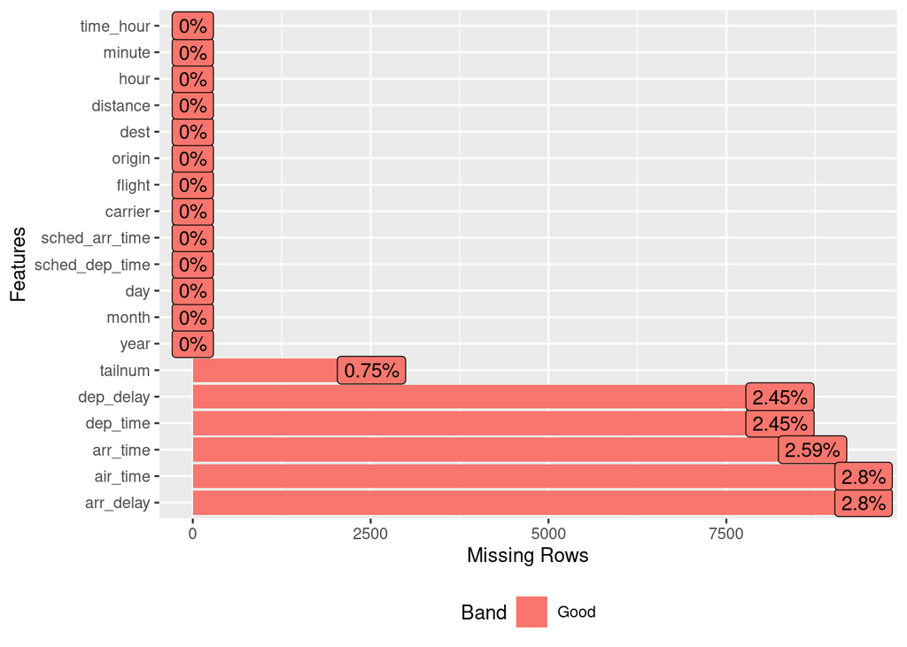

```r
plot_missing(flights)
```

[Hier](https://cran.r-project.org/web/packages/DataExplorer/vignettes/dataexplorer-intro.html) findet sich eine Einführung in das Paket.

Wie wiele Zeilen ohne fehlende Werte gibt es im Datensatz (absolut und anteilig)?

```r
flights %>%
  drop_na() %>%
  nrow()
```

```
## [1] 327346
```

Identifizieren Sie alle Flüge, deren Verspätung (Abflug) mehr als 3 SD über dem Mittelwert (aller Flüge) liegt!